# Data Manipulation and Visualisation in R

Mark Dunning

Last modified: 20 Apr 2016

## Motivation

Spreadsheets are a common entry-point for many types of analyses. Whilst they are great for exploring, visualising data in an interactive and intuitive manner they are not ideal for many production-level analyses.

- Tedious and time-consuming to repeatedly process multiple files
- Error-prone
- Unwieldy and difficult to deal with large amounts of data
- How can you (or someone else?) repeat what you did?

[figure not shown]

This course aims to translate how we think of data in spreadsheets to a series of operations that can be performed and chained together in R.

A data analysis can be broken-down into several stages. There is, however, no such thing as a typical analysis. Most datasets we will encounter will have their own issues and problems that need fixing. We will also need to spend a lot of time visualising our data in different ways in order to gain insights. For every figure or table presented in a paper, there may be tens of hundreds of exploratory analyses that were generated along the way. We will show how such exploratory analysis can be performed in R.

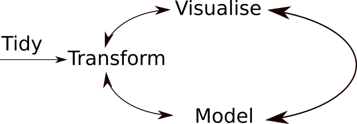

(from Hadley Wickham’s workshop at [useR2014](http://datascience.la/hadley-wickhams-dplyr-tutorial-at-user-2014-part-1/))

Unfortunately, in R there are many hundreds (thousands!) of functions for us to choose from to achieve our goals, and everyone will have their own set of favourites. The tools we will meet today help us to explore data in a consistent and “pipeline-able” manner.

Hadley also has these words of advice that we should bear in mind as we proceed through the course.

> Whenever you’re learning a new tool, for a long time you’re going to suck… But the good news is that is typical, that’s something that happens to everyone, and it’s only temporary.

## Advantages of R

[figure not shown]

The R programming language is now recognised beyond the academic community as an effect solution for data analysis and visualisation. [Notable users of R](http://www.revolutionanalytics.com/companies-using-r) include [Facebook](http://blog.revolutionanalytics.com/2010/12/analysis-of-facebook-status-updates.html), [google](http://blog.revolutionanalytics.com/2009/05/google-using-r-to-analyze-effectiveness-of-tv-ads.html),[buzzfeed](http://blog.revolutionanalytics.com/2015/12/buzzfeed-uses-r-for-data-journalism.html), [Microsoft](http://blog.revolutionanalytics.com/2014/05/microsoft-uses-r-for-xbox-matchmaking.html) (who recently [invested](http://blogs.microsoft.com/blog/2015/01/23/microsoft-acquire-revolution-analytics-help-customers-find-big-data-value-advanced-statistical-analysis/) in a commerical provider of R), and the [New York Times](http://blog.revolutionanalytics.com/2011/03/how-the-new-york-times-uses-r-for-data-visualization.html).

The main advantages are;

- Open-source
- Cross-platform
- Access to existing visualisation / statistical tools
- Flexibility
- Visualisation and interactivity
- Facilitaing *Reproducible Research*

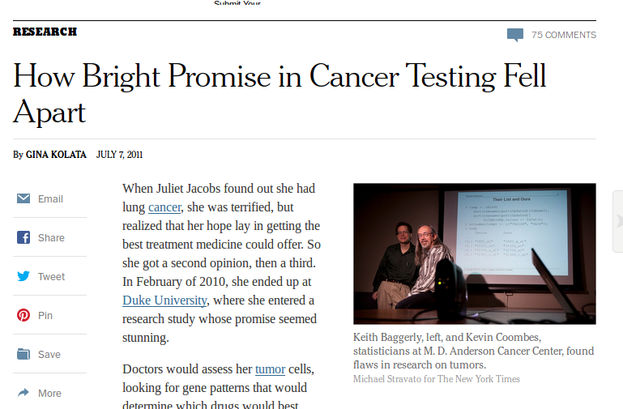

Two Biostatiscians (later termed ‘*Forensic Bioinformaticians*’) from M.D. Anderson used R extensively during their re-analysis and investigation of a Clinical Prognostication paper from Duke. The subsequent [scandal](https://www.youtube.com/watch?v=W5sZTNPMQRM) put Reproducible Research at the forefront of everyone’s mind.

Keith Baggerly’s [talk](https://www.youtube.com/watch?v=7gYIs7uYbMo) is highy-recommended.

## Support for R

- Online forums such as [Stack Overflow](http://stackoverflow.com/questions/tagged/r) regularly feature R
- [Blogs](http://www.r-bloggers.com/)
- Local [user groups](http://www.meetup.com/Cambridge-R-Users-Group-Meetup/)
- Documentation via `?` or `help.start()`

## Various platforms supported

- Release 3.2.2 (August 2015)
  - Base package and Contributed packages (general purpose extras)
  - 8280 available packages as of Wed Apr 20 12:46:45 2016
- Download from http://mirrors.ebi.ac.uk/CRAN/
- Windows, Mac and Linux versions available
- Executed using command line, or a graphical user interface (GUI)
- On this course, we use the RStudio GUI (www.rstudio.com)
- Everything you need is installed on the training machines
- If you are using your own machine, download both R and RStudio

## Launching R Using RStudio

To launch RStudio, find the RStudio icon in the menu bar on the left of the screen and click

[figure not shown]

## Basic concepts in R - command line calculation

- The command line can be used as a calculator. Type:

```r
2 + 2
```

```
## [1] 4
```

```r
20/5 - sqrt(25) + 3^2
```

```
## [1] 8
```

```r
sin(pi/2)
```

```
## [1] 1
```

Note: The number in the square brackets is an indicator of the position in the output. In this case the output is a ‘vector’ of length 1 (i.e. a single number). More on vectors coming up…

## Basic concepts in R - variables

- A variable is a letter or word which takes (or contains) a value. We use the assignment ‘operator’, `<-`

```r
x <- 10
x
```

```
## [1] 10
```

```r
myNumber <- 25
myNumber
```

```
## [1] 25
```

- We can perform arithmetic on variables:

```r
sqrt(myNumber)
```

```
## [1] 5
```

- We can add variables together:

```r
x + myNumber
```

```
## [1] 35
```

## Basic concepts in R - variables

- We can change the value of an existing variable:

```r
x <- 21
x
```

```
## [1] 21
```

- We can set one variable to equal the value of another variable:

```r
x <- myNumber
x
```

```
## [1] 25
```

- We can modify the contents of a variable:

```r
myNumber <- myNumber + sqrt(16)
myNumber
```

```
## [1] 29
```

## Basic concepts in R - functions

- **Functions** in R perform operations on **arguments** (the inputs(s) to the function). We have already used:

```r
sin(x)
```

this returns the sine of x. In this case the function has one argument: **x**. Arguments are always contained in parentheses – curved brackets, **()** – separated by commas.

Arguments can be named or unnamed, but if they are unnamed they must be ordered (we will see later how to find the right order). When testing code, it is easier and safer to name the arguments

```r
seq(from = 2, to = 20, by = 4)
```

```
## [1]  2  6 10 14 18
```

```r
seq(2, 20, 4)
```

```
## [1]  2  6 10 14 18
```

Arguments can have *default* values, meaning we do not need to specify values for these in order to run the function.

`rnorm` is a function that will generate a series of values from a *normal distribution*. In order to use the function, we need to tell R how many values we want

```r
rnorm(n=10)
```

```
##  [1]  0.2138392 -1.0579933 -1.9490235 -1.8915200  0.3213608 -0.4495536
##  [7] -0.6878514  0.8612798 -0.6746111  1.4310943
```

The normal distribution is defined by a mean and standard deviation. However, we didn’t tell R what mean and standard deviation we wanted. So how does R know what to do? All arguments to a function and their default values are listed in the help page

(*N.B sometimes help pages can describe more than one function*)

```r
?rnorm
```

In this case, we see that the defaults for mean and standard deviation are 0 and 1.

```r
rnorm(n=10, mean=2,sd=3)
```

```
##  [1]  1.81617764 -0.05281409  3.35975441  2.44735080  3.31291812
##  [6]  4.84689446 -1.47415366  1.24623506  4.37176235 -1.97267160
```

## Basic concepts in R - vectors

- The basic data structure in R is a **vector** – an ordered collection of values.
- R treats even single values as 1-element vectors.
- The function `c` *combines* its arguments into a vector:

```r
x <- c(3,4,5,6)
x
```

```
## [1] 3 4 5 6
```

- The square brackets `[]` indicate the position within the vector (the *index*). We can extract individual elements by using the `[]` notation:

```r
x[1]
```

```
## [1] 3
```

```r
x[4]
```

```
## [1] 6
```

- We can even put a vector inside the square brackets: (*vector indexing*)

```r
y <- c(2,3)
x[y]
```

```
## [1] 4 5
```

A vector can also contain text; called a character vector. Such a vector can also be constructed using the `c` function.

```r
x <- c("A","B","C","D")
```

Another useful type of data that we will see is the *logical* or *boolean* which can take either the values of `TRUE` or `FALSE`

```r
x <- c(TRUE,TRUE,FALSE)
```

All items in the vector **must** be the same type. If you attempt anything else, R will convert all values to the same type.

```r
x <- c(1, 2, "three")
x
```

```
## [1] "1"     "2"     "three"
```

## Vector arithmetic

- When applying all standard arithmetic operations to vectors, application is element-wise

```r
x <- 1:10
y <- x*2
y
```

```
##  [1]  2  4  6  8 10 12 14 16 18 20
```

```r
z <- x^2

x + y
```

```
##  [1]  3  6  9 12 15 18 21 24 27 30
```

## The data frame

The data frame object in R allows us to work with “tabular” data, like we might be used to dealing with in Excel, where our data can be thought of having rows and columns. The values in each column have to all be of the same type (i.e. all numbers or all text).

The `iris` data frame is a classic dataset that is built into R. To load these data, we use the `data` function with the name `iris` (notice no quotation marks) in brackets. The data frame can then be printed to screen by typing it’s name (`iris`).

N.B. As we will see later, we tend to read datasets into R using `read.csv`, `read.delim` or similar functions.

```r
data(iris)
```

The `View` function will create a tab in RStudio that we can use to browse the data.

```r
View(iris)
```

A commonly-used function is `head` which will print the first six rows to the screen, otherwise R will attempt to show the entire object (very annoying for large objects!).

```r
head(iris)
```

```
##   Sepal.Length Sepal.Width Petal.Length Petal.Width Species
## 1          5.1         3.5          1.4         0.2  setosa
## 2          4.9         3.0          1.4         0.2  setosa
## 3          4.7         3.2          1.3         0.2  setosa
## 4          4.6         3.1          1.5         0.2  setosa
## 5          5.0         3.6          1.4         0.2  setosa
## 6          5.4         3.9          1.7         0.4  setosa
```

We can notice that there are `nrow(iris)` rows and `ncol(iris)` columns. There is also a function in R, `dim`, that will print the dimensions for us. The `colnames` function will also print the names of the functions.

```r
dim(iris)
```

```
## [1] 150   5
```

```r
colnames(iris)
```

```
## [1] "Sepal.Length" "Sepal.Width"  "Petal.Length" "Petal.Width"
## [5] "Species"
```

Data for a particular column can be accessed using what is known as the `$` operator

```r
iris$Sepal.Length
iris$Species
```

Here, `iris$Species` is a new type of object in R. It is an example of a *factor*, which is a type of object used frequently in data analysis. Rather than being merely a character string, the vector has a set of levels; **setosa, versicolor, virginica**. This allows us to perform various analyses that treat the values as belonging to different categories. For example, we might look to compare the distribution of length, width of different species and perform statistical testing. Having our data as factors aids such analyses.

The `summary` function is a versatile function to summarise an object. For this dataset, it reports the distribution of values in the first four columns, and a summary of the *categories* in the final column.

```r
summary(iris)
```

```
##   Sepal.Length    Sepal.Width     Petal.Length    Petal.Width
##  Min.   :4.300   Min.   :2.000   Min.   :1.000   Min.   :0.100
##  1st Qu.:5.100   1st Qu.:2.800   1st Qu.:1.600   1st Qu.:0.300
##  Median :5.800   Median :3.000   Median :4.350   Median :1.300
##  Mean   :5.843   Mean   :3.057   Mean   :3.758   Mean   :1.199
##  3rd Qu.:6.400   3rd Qu.:3.300   3rd Qu.:5.100   3rd Qu.:1.800
##  Max.   :7.900   Max.   :4.400   Max.   :6.900   Max.   :2.500
##        Species
##  setosa    :50
##  versicolor:50
##  virginica :50
##
##
##
```

We will explore plotting in much more detail later on the course. R provides a wide-variety of [plotting options](http://www.statmethods.net/graphs/index.html) as part of the *base* distribution. Without going into too much detail, the following will create a boxplot of the values in `Sepal.Length` column categorised into the different values of `Species`.

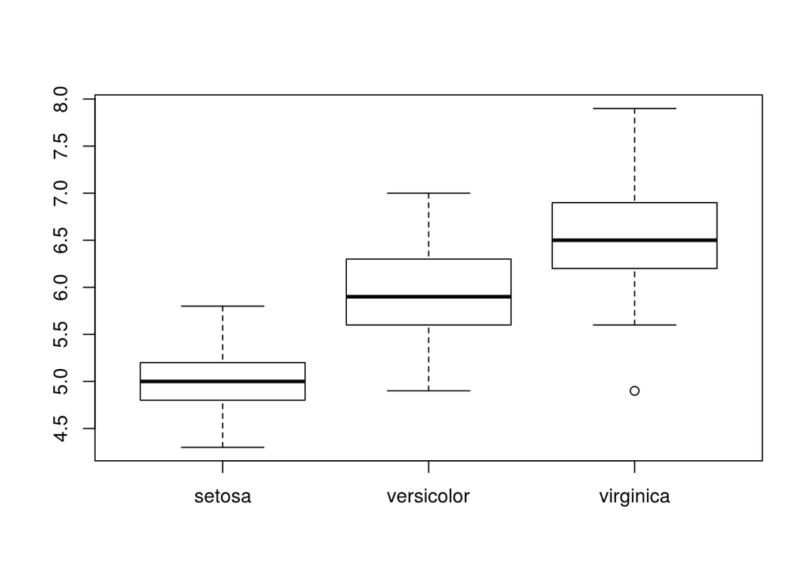

```r
boxplot(Sepal.Length~Species,iris)
```

## How can R enable Reproducible Research?

Within RStudio we can write *markdown* documents, which are a mix of R code and text. The markdown file can be used as a template to generated PDF, HTML, or even Word documents. The clever bit is that all R code in the template can be execute and the results displayed (tables, graphics etc) along with the code. The compiled document can be passed to your collaborators and they should be able to generate the same results. Alternatively, you can choose to hide the code if your PI just wants to see the results, and not neccesarily what packages, parameters you used. Long-term R users may have heard of *Sweave*. Markdown is the same concept, but an easier to write (and read) syntax

Markdown can also generate presentations and courses. Indeed, all the [materials for this course](https://github.com/cambiotraining/r-intermediate) were written in markdown.

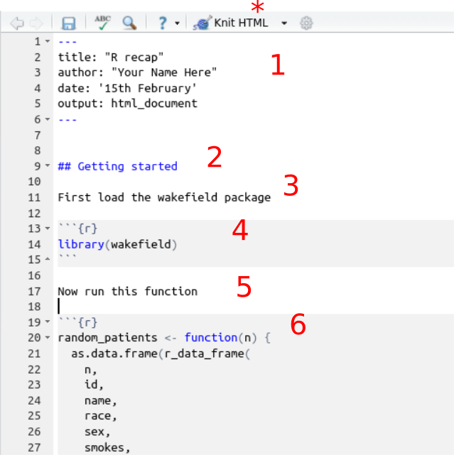

1. Header information
2. Section heading
3. Plain text
4. R code to be run
5. Plain text
6. R code to be run

Each line of R code can be executed in the R console by placing the cursor on the line and pressing `CTRL + ENTER`. You can also highlight multiple lines of code. NB. You do not need to highlight to the backtick (```) symbols. Hitting the knit button (*) will run all R code in order and (providing there are no errors!) you will get a PDF or HTML document. The resultant document will contain all the plain text you wrote, the R code, and any outputs (including graphs, tables etc) that R produced. You can then distribute this document to have a reproducible account of your analysis.

## How to use the template

- Change your name, add a title and date in the header section
- Add notes, explanations of code etc in the white space between code chunks. You can add new lines with `ENTER`. Clicking the `?` next to the `Knit HTML` button will give more information about how to format this text. You can introduce **bold** and *italics* for example.
- Some code chunks are left blank. These are for you to write the R code required to answer the questions
- You can try to knit the document at any point to see how it looks

## A Short Analysis Example

- Open the file `iris.Rmd`
  - this contains the code we have just looked at to load and visualise the `iris` dataset
  - change the header information to contain your name and the date
  - compile the document by pressing the *Knit HTML* button. This should produce a file called `iris.html`
  - modify the Rmd file so that the boxplot of the `Petal.Length` variable is produced, rather than `Sepal.Length`